## 810197539

# Introduction

We are going to train a model to classify x-ray images of chest to recognize that person has `Covid` or not.

This is done using `Keras` in `Tenorflow`.

Also we will examine some parameters and function on this model.

```python
!cp "/content/drive/MyDrive/AI-CA5/xray.zip" .
```

```python
!unzip xray.zip
```

[output not shown]

[output cut: 4946 more lines]

[output not shown]

```python
from tensorflow.keras import *
import matplotlib.pyplot as plt
import matplotlib.image as mpimage
import numpy as np
from sklearn.metrics import classification_report
from keras import backend as K
```

```python
data_generator = preprocessing.image.ImageDataGenerator()
```

```python
train_data = data_generator.flow_from_directory("/content/Data/train", target_size=(80, 80), color_mode="grayscale", batch_size=32)
```

```
Found 5144 images belonging to 3 classes.
```

```python
test_data = data_generator.flow_from_directory("/content/Data/test", target_size=(80, 80), color_mode="grayscale", batch_size=32)
```

```
Found 1288 images belonging to 3 classes.
```

```python
train_classes = [0, 0, 0]
for label in train_data.classes:
  train_classes[label] += 1
```

```python
test_classes = [0, 0, 0]
for label in test_data.classes:
  test_classes[label] += 1
```

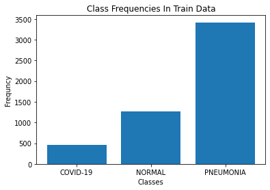

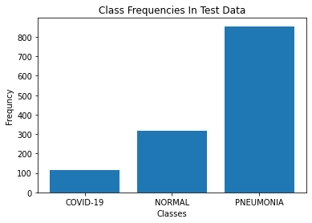

```python
plt.bar(["COVID-19", "NORMAL", "PNEUMONIA"], train_classes)
plt.title("Class Frequencies In Train Data")
plt.ylabel("Frequncy")
plt.xlabel("Classes")
plt.show()
plt.bar(["COVID-19", "NORMAL", "PNEUMONIA"], test_classes)
plt.title("Class Frequencies In Test Data")
plt.ylabel("Frequncy")
plt.xlabel("Classes")
plt.show()
```

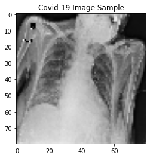

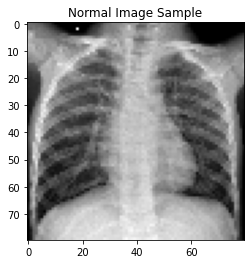

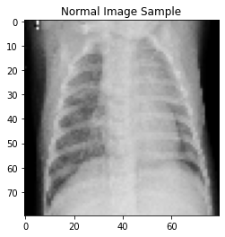

```python
img = preprocessing.image.load_img("/content/Data/test/COVID19/COVID19(460).jpg", target_size=(80, 80))
imgplot = plt.imshow(img)
plt.title("Covid-19 Image Sample")
plt.show()
img = preprocessing.image.load_img("/content/Data/test/NORMAL/NORMAL(1266).jpg", target_size=(80, 80))
imgplot = plt.imshow(img)
plt.title("Normal Image Sample")
plt.show()
img = preprocessing.image.load_img("/content/Data/test/PNEUMONIA/PNEUMONIA(3418).jpg", target_size=(80, 80))
imgplot = plt.imshow(img)
plt.title("Normal Image Sample")
plt.show()
```

```python
def Recall(y_true, y_pred):
    true_positives = K.sum(K.round(K.clip(y_true * y_pred, 0, 1)))
    possible_positives = K.sum(K.round(K.clip(y_true, 0, 1)))
    recall = true_positives / (possible_positives + K.epsilon())
    return recall

def Precision(y_true, y_pred):
    true_positives = K.sum(K.round(K.clip(y_true * y_pred, 0, 1)))
    predicted_positives = K.sum(K.round(K.clip(y_pred, 0, 1)))
    precision = true_positives / (predicted_positives + K.epsilon())
    return precision

def F1(y_true, y_pred):
    precision = Precision(y_true, y_pred)
    recall = Recall(y_true, y_pred)
    return 2*((precision*recall)/(precision+recall+K.epsilon()))
```

```python
input_layer = layers.Input(shape=(80,80,1))
output_layer = layers.Flatten()(input_layer)
output_layer = layers.Dense(1024, activation='relu')(output_layer)
output_layer = layers.Dense(100, activation='relu')(output_layer)
output_layer = layers.Dense(3, activation='softmax')(output_layer)
model = models.Model(inputs=input_layer, outputs=output_layer)
model.compile(optimizer=optimizers.SGD(learning_rate=0.01), loss='categorical_crossentropy', metrics=['accuracy', Recall, Precision, F1])
```

```python
model.summary()
```

```
Model: "model"
_________________________________________________________________
Layer (type)                 Output Shape              Param #
=================================================================
input_1 (InputLayer)         [(None, 80, 80, 1)]       0
_________________________________________________________________
flatten (Flatten)            (None, 6400)              0
_________________________________________________________________
dense (Dense)                (None, 1024)              6554624
_________________________________________________________________
dense_1 (Dense)              (None, 100)               102500
_________________________________________________________________
dense_2 (Dense)              (None, 3)                 303
=================================================================
Total params: 6,657,427
Trainable params: 6,657,427
Non-trainable params: 0
_________________________________________________________________
```

## What are these outputs?

First of all we can see the name of layers. But about parameter what are they?

Easily they show number of total weights and biases. For example we can see for first `Dense` layer we have `6554624` which is number of weights:

1024(number of neurons) x 6400(number of layer input) = 6553600

, plus number of biases which is `1024`.

```python
history_relu = model.fit(train_data, validation_data=test_data , epochs=10)
```

```python
loss, accuracy, recall, precision, f1 = model.evaluate(test_data, verbose=0)
print("Loss = ",loss)
print("Accuarcy = ",accuracy)
print("Recall = ",recall)
print("Precision = ",precision)
print("F1 = ",f1)
```

```
Loss =  nan
Accuarcy =  0.09006211161613464
Recall =  nan
Precision =  nan
F1 =  nan
```

## Why we have NaN values?

As you remember here values are high. Also `Relu` function is as below:

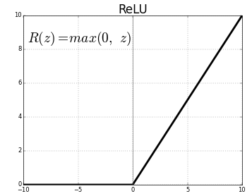

So we can see that when value is `positive`, we does not change value. This is not good because we does not value and after some time we get high values and then `overflow` occurs.

The way to resolve this problem, is to normalize value such as dividing by max. In this way we limitize values.

```python
input_layer = layers.Input(shape=(80,80,1))
output_layer = layers.Flatten()(input_layer)
output_layer = layers.Dense(1024, activation='tanh')(output_layer)
output_layer = layers.Dense(100, activation='tanh')(output_layer)
output_layer = layers.Dense(3, activation='softmax')(output_layer)
model = models.Model(inputs=input_layer, outputs=output_layer)
model.compile(optimizer=optimizers.SGD(learning_rate=0.01), loss='categorical_crossentropy', metrics=['accuracy', Recall, Precision, F1])
history_tanh = model.fit(train_data, validation_data=test_data , epochs=10)
```

```python
loss, accuracy, recall, precision, f1 = model.evaluate(test_data, verbose=0)
print("Loss = ",loss)
print("Accuarcy = ",accuracy)
print("Recall = ",recall)
print("Precision = ",precision)
print("F1 = ",f1)
```

```
Loss =  0.8392606973648071
Accuarcy =  0.6638198494911194
Recall =  0.6631097793579102
Precision =  0.6631097793579102
F1 =  0.6631097197532654
```

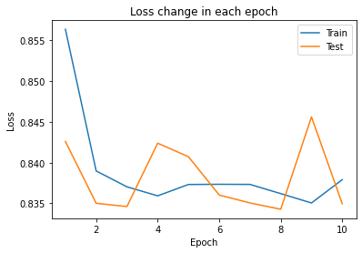

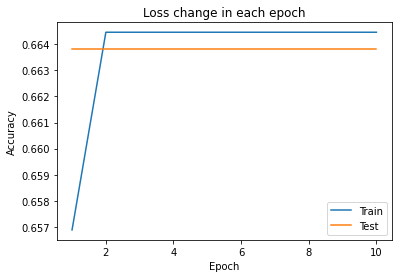

```python
plt.plot([1,2,3,4,5,6,7,8,9,10], history_tanh.history["loss"])
plt.plot([1,2,3,4,5,6,7,8,9,10], history_tanh.history["val_loss"])
plt.legend(["Train", "Test"])
plt.xlabel('Epoch')
plt.ylabel('Loss')
plt.title('Loss change in each epoch')
plt.show()
plt.plot([1,2,3,4,5,6,7,8,9,10], history_tanh.history["accuracy"])
plt.plot([1,2,3,4,5,6,7,8,9,10], history_tanh.history["val_accuracy"])
plt.legend(["Train", "Test"])
plt.xlabel('Epoch')
plt.ylabel('Accuracy')
plt.title('Loss change in each epoch')
plt.show()
```

## Why `tanh` does not make good prediction?

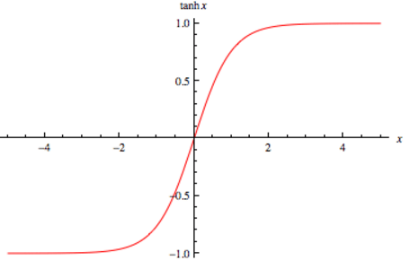

Tanh does not make `NaN` values for us because it limitize values, but also this way of limitization is not good. Because is classification probabilities make `Label` for us. No many of our values are huge numbers because `tanh` is same for them in `infinity`(equals to one) so we have a lot of equal values at end and can not make good prediction.

## Similiraty in two above models

Both above models problem is huge values. `Relu` makes `NaN` value when huge values come and `Tanh` map a lot values to same thing(for huge values it makes 1). So this make both models to have bad results.

The way to resolve this is to use normalziation such as dividing by max.

```python
data_generator = preprocessing.image.ImageDataGenerator(rescale=1/255.0)
train_data = data_generator.flow_from_directory("/content/Data/train", target_size=(80, 80), color_mode="grayscale", batch_size=32)
test_data = data_generator.flow_from_directory("/content/Data/test", target_size=(80, 80), color_mode="grayscale", batch_size=32)
```

```
Found 5144 images belonging to 3 classes.
Found 1288 images belonging to 3 classes.
```

```python
input_layer = layers.Input(shape=(80,80,1))
output_layer = layers.Flatten()(input_layer)
output_layer = layers.Dense(1024, activation='relu')(output_layer)
output_layer = layers.Dense(1024, activation='relu')(output_layer)
output_layer = layers.Dense(3, activation='softmax')(output_layer)
model = models.Model(inputs=input_layer, outputs=output_layer)
model.compile(optimizer=optimizers.SGD(learning_rate=0.01), loss='categorical_crossentropy', metrics=['accuracy', Recall, Precision, F1])
history1 = model.fit(train_data, validation_data=test_data , epochs=10)
```

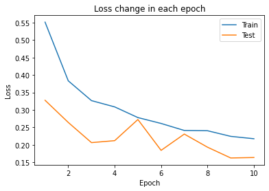

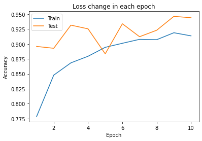

```python
plt.plot([1,2,3,4,5,6,7,8,9,10], history1.history["loss"])
plt.plot([1,2,3,4,5,6,7,8,9,10], history1.history["val_loss"])
plt.legend(["Train", "Test"])
plt.xlabel('Epoch')
plt.ylabel('Loss')
plt.title('Loss change in each epoch')
plt.show()
plt.plot([1,2,3,4,5,6,7,8,9,10], history1.history["accuracy"])
plt.plot([1,2,3,4,5,6,7,8,9,10], history1.history["val_accuracy"])
plt.legend(["Train", "Test"])
plt.xlabel('Epoch')
plt.ylabel('Accuracy')
plt.title('Loss change in each epoch')
plt.show()
```

```python
loss, accuracy, recall, precision, f1 = model.evaluate(test_data, verbose=0)
print("Loss = ",loss)
print("Accuarcy = ",accuracy)
print("Recall = ",recall)
print("Precision = ",precision)
print("F1 = ",f1)
```

[output not shown]

```python
input_layer = layers.Input(shape=(80,80,1))
output_layer = layers.Flatten()(input_layer)
output_layer = layers.Dense(100, activation='relu')(output_layer)
output_layer = layers.Dense(100, activation='relu')(output_layer)
output_layer = layers.Dense(3, activation='softmax')(output_layer)
model = models.Model(inputs=input_layer, outputs=output_layer)
model.compile(optimizer=optimizers.SGD(learning_rate=0.01), loss='categorical_crossentropy', metrics=['accuracy', Recall, Precision, F1])
history2 = model.fit(train_data, validation_data=test_data , epochs=10)
```

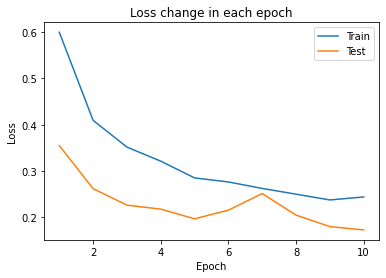

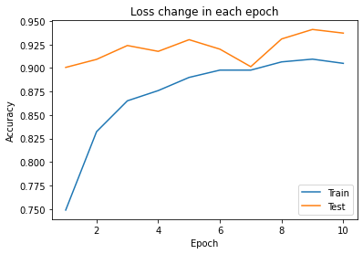

```python
plt.plot([1,2,3,4,5,6,7,8,9,10], history2.history["loss"])
plt.plot([1,2,3,4,5,6,7,8,9,10], history2.history["val_loss"])
plt.legend(["Train", "Test"])
plt.xlabel('Epoch')
plt.ylabel('Loss')
plt.title('Loss change in each epoch')
plt.show()
plt.plot([1,2,3,4,5,6,7,8,9,10], history2.history["accuracy"])
plt.plot([1,2,3,4,5,6,7,8,9,10], history2.history["val_accuracy"])
plt.legend(["Train", "Test"])
plt.xlabel('Epoch')
plt.ylabel('Accuracy')
plt.title('Loss change in each epoch')
plt.show()
```

```python
loss, accuracy, recall, precision, f1 = model.evaluate(test_data, verbose=0)
print("Loss = ",loss)
print("Accuarcy = ",accuracy)
print("Recall = ",recall)
print("Precision = ",precision)
print("F1 = ",f1)
```

```
Loss =  0.1713411509990692
Accuarcy =  0.9394409656524658
Recall =  0.9367377758026123
Precision =  0.9462266564369202
F1 =  0.9413949251174927
```

```python
input_layer = layers.Input(shape=(80,80,1))
output_layer = layers.Flatten()(input_layer)
output_layer = layers.Dense(100, activation='relu')(output_layer)
output_layer = layers.Dense(1024, activation='relu')(output_layer)
output_layer = layers.Dense(3, activation='softmax')(output_layer)
model = models.Model(inputs=input_layer, outputs=output_layer)
model.compile(optimizer=optimizers.SGD(learning_rate=0.01), loss='categorical_crossentropy', metrics=['accuracy', Recall, Precision, F1])
history3 = model.fit(train_data, validation_data=test_data , epochs=10)
```

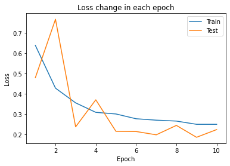

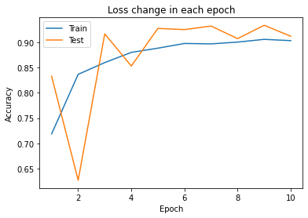

```python
plt.plot([1,2,3,4,5,6,7,8,9,10], history3.history["loss"])
plt.plot([1,2,3,4,5,6,7,8,9,10], history3.history["val_loss"])
plt.legend(["Train", "Test"])
plt.xlabel('Epoch')
plt.ylabel('Loss')
plt.title('Loss change in each epoch')
plt.show()
plt.plot([1,2,3,4,5,6,7,8,9,10], history3.history["accuracy"])
plt.plot([1,2,3,4,5,6,7,8,9,10], history3.history["val_accuracy"])
plt.legend(["Train", "Test"])
plt.xlabel('Epoch')
plt.ylabel('Accuracy')
plt.title('Loss change in each epoch')
plt.show()
```

```python
loss, accuracy, recall, precision, f1 = model.evaluate(test_data, verbose=0)
print("Loss = ",loss)
print("Accuarcy = ",accuracy)
print("Recall = ",recall)
print("Precision = ",precision)
print("F1 = ",f1)
```

```
Loss =  0.18226024508476257
Accuarcy =  0.9378882050514221
Recall =  0.9336889982223511
Precision =  0.9409667253494263
F1 =  0.9372701644897461
```

```python
input_layer = layers.Input(shape=(80,80,1))
output_layer = layers.Flatten()(input_layer)
output_layer = layers.Dense(1024, activation='relu')(output_layer)
output_layer = layers.Dense(100, activation='relu')(output_layer)
output_layer = layers.Dense(3, activation='softmax')(output_layer)
model = models.Model(inputs=input_layer, outputs=output_layer)
model.compile(optimizer=optimizers.SGD(learning_rate=0.01), loss='categorical_crossentropy', metrics=['accuracy', Recall, Precision, F1])
history4 = model.fit(train_data, validation_data=test_data , epochs=10)
```

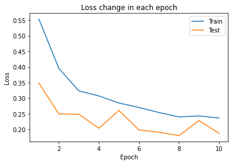

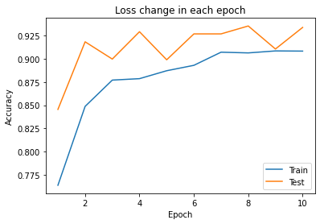

```python
plt.plot([1,2,3,4,5,6,7,8,9,10], history4.history["loss"])
plt.plot([1,2,3,4,5,6,7,8,9,10], history4.history["val_loss"])
plt.legend(["Train", "Test"])
plt.xlabel('Epoch')
plt.ylabel('Loss')
plt.title('Loss change in each epoch')
plt.show()
plt.plot([1,2,3,4,5,6,7,8,9,10], history4.history["accuracy"])
plt.plot([1,2,3,4,5,6,7,8,9,10], history4.history["val_accuracy"])
plt.legend(["Train", "Test"])
plt.xlabel('Epoch')
plt.ylabel('Accuracy')
plt.title('Loss change in each epoch')
plt.show()
```

```python
loss, accuracy, recall, precision, f1 = model.evaluate(test_data, verbose=0)
print("Loss = ",loss)
print("Accuarcy = ",accuracy)
print("Recall = ",recall)
print("Precision = ",precision)
print("F1 = ",f1)
```

```
Loss =  0.18839043378829956
Accuarcy =  0.9270186424255371
Recall =  0.9253048896789551
Precision =  0.9311074018478394
F1 =  0.9281600117683411
```

```python
input_layer = layers.Input(shape=(80,80,1))
output_layer = layers.Flatten()(input_layer)
output_layer = layers.Dense(100, activation='relu')(output_layer)
output_layer = layers.Dense(1024, activation='relu')(output_layer)
output_layer = layers.Dense(100, activation='relu')(output_layer)
output_layer = layers.Dense(3, activation='softmax')(output_layer)
model = models.Model(inputs=input_layer, outputs=output_layer)
model.compile(optimizer=optimizers.SGD(learning_rate=0.01), loss='categorical_crossentropy', metrics=['accuracy', Recall, Precision, F1])
history5 = model.fit(train_data, validation_data=test_data , epochs=10)
```

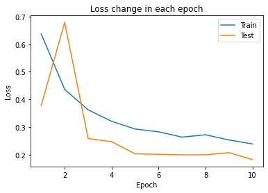

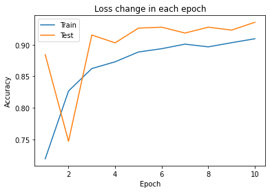

```python
plt.plot([1,2,3,4,5,6,7,8,9,10], history5.history["loss"])
plt.plot([1,2,3,4,5,6,7,8,9,10], history5.history["val_loss"])
plt.legend(["Train", "Test"])
plt.xlabel('Epoch')
plt.ylabel('Loss')
plt.title('Loss change in each epoch')
plt.show()
plt.plot([1,2,3,4,5,6,7,8,9,10], history5.history["accuracy"])
plt.plot([1,2,3,4,5,6,7,8,9,10], history5.history["val_accuracy"])
plt.legend(["Train", "Test"])
plt.xlabel('Epoch')
plt.ylabel('Accuracy')
plt.title('Loss change in each epoch')
plt.show()
```

```python
loss, accuracy, recall, precision, f1 = model.evaluate(test_data, verbose=0)
print("Loss = ",loss)
print("Accuarcy = ",accuracy)
print("Recall = ",recall)
print("Precision = ",precision)
print("F1 = ",f1)
```

```
Loss =  0.17501962184906006
Accuarcy =  0.9394409656524658
Recall =  0.9375
Precision =  0.9453333616256714
F1 =  0.9413319826126099
```

```python
input_layer = layers.Input(shape=(80,80,1))
output_layer = layers.Flatten()(input_layer)
output_layer = layers.Dense(100, activation='relu')(output_layer)
output_layer = layers.Dense(1024, activation='relu')(output_layer)
output_layer = layers.Dense(1024, activation='relu')(output_layer)
output_layer = layers.Dense(3, activation='softmax')(output_layer)
model = models.Model(inputs=input_layer, outputs=output_layer)
model.compile(optimizer=optimizers.SGD(learning_rate=0.01), loss='categorical_crossentropy', metrics=['accuracy', Recall, Precision, F1])
history6 = model.fit(train_data, validation_data=test_data , epochs=10)
```

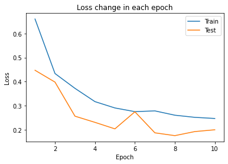

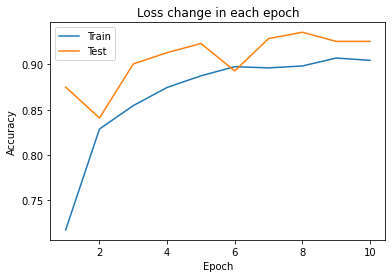

```python
plt.plot([1,2,3,4,5,6,7,8,9,10], history6.history["loss"])
plt.plot([1,2,3,4,5,6,7,8,9,10], history6.history["val_loss"])
plt.legend(["Train", "Test"])
plt.xlabel('Epoch')
plt.ylabel('Loss')
plt.title('Loss change in each epoch')
plt.show()
plt.plot([1,2,3,4,5,6,7,8,9,10], history6.history["accuracy"])
plt.plot([1,2,3,4,5,6,7,8,9,10], history6.history["val_accuracy"])
plt.legend(["Train", "Test"])
plt.xlabel('Epoch')
plt.ylabel('Accuracy')
plt.title('Loss change in each epoch')
plt.show()
```

```python
loss, accuracy, recall, precision, f1 = model.evaluate(test_data, verbose=0)
print("Loss = ",loss)
print("Accuarcy = ",accuracy)
print("Recall = ",recall)
print("Precision = ",precision)
print("F1 = ",f1)
```

[output not shown]

```python
input_layer = layers.Input(shape=(80,80,1))
output_layer = layers.Flatten()(input_layer)
output_layer = layers.Dense(100, activation='relu')(output_layer)
output_layer = layers.Dense(100, activation='relu')(output_layer)
output_layer = layers.Dense(1024, activation='relu')(output_layer)
output_layer = layers.Dense(3, activation='softmax')(output_layer)
model = models.Model(inputs=input_layer, outputs=output_layer)
model.compile(optimizer=optimizers.SGD(learning_rate=0.01), loss='categorical_crossentropy', metrics=['accuracy', Recall, Precision, F1])
history7 = model.fit(train_data, validation_data=test_data , epochs=10)
```

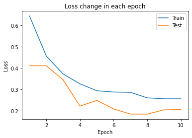

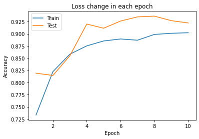

```python
plt.plot([1,2,3,4,5,6,7,8,9,10], history7.history["loss"])
plt.plot([1,2,3,4,5,6,7,8,9,10], history7.history["val_loss"])
plt.legend(["Train", "Test"])
plt.xlabel('Epoch')
plt.ylabel('Loss')
plt.title('Loss change in each epoch')
plt.show()
plt.plot([1,2,3,4,5,6,7,8,9,10], history7.history["accuracy"])
plt.plot([1,2,3,4,5,6,7,8,9,10], history7.history["val_accuracy"])
plt.legend(["Train", "Test"])
plt.xlabel('Epoch')
plt.ylabel('Accuracy')
plt.title('Loss change in each epoch')
plt.show()
```

```python
loss, accuracy, recall, precision, f1 = model.evaluate(test_data, verbose=0)
print("Loss = ",loss)
print("Accuarcy = ",accuracy)
print("Recall = ",recall)
print("Precision = ",precision)
print("F1 = ",f1)
```

```
Loss =  0.18585123121738434
Accuarcy =  0.9378882050514221
Recall =  0.9375
Precision =  0.9418026804924011
F1 =  0.9396046996116638
```

What do stochastic gradient descent optimisers do?

Recall that the vanilla stochastic gradient descent (SGD) updates weights by subtracting the current weight by a factor (i.e. α, the learning rate) of its gradient.

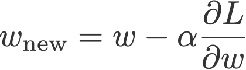

But what is **momentom**?

As you saw, updating is just based on current gradient. Instead of depending only on the current gradient to update the weight, gradient descent with momentum (Polyak, 1964) replaces the current gradient with m (“momentum”), which is an aggregate of gradients. This aggregate is the exponential moving average of current and past gradients (i.e. up to time t).

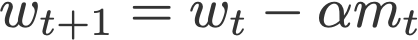

#### Advantage

Momentum is known to speed up learning and to help not getting stuck in local minima.

```python
input_layer = layers.Input(shape=(80,80,1))
output_layer = layers.Flatten()(input_layer)
output_layer = layers.Dense(100, activation='relu')(output_layer)
output_layer = layers.Dense(100, activation='relu')(output_layer)
output_layer = layers.Dense(3, activation='softmax')(output_layer)
model = models.Model(inputs=input_layer, outputs=output_layer)
model.compile(optimizer=optimizers.SGD(learning_rate=0.01, momentum=0.5), loss='categorical_crossentropy', metrics=['accuracy', Recall, Precision, F1])
history = model.fit(train_data, validation_data=test_data , epochs=10)
```

```python
loss, accuracy, recall, precision, f1 = model.evaluate(test_data, verbose=0)
print("Loss = ",loss)
print("Accuarcy = ",accuracy)
print("Recall = ",recall)
print("Precision = ",precision)
print("F1 = ",f1)
```

```
Loss =  0.2089689075946808
Accuarcy =  0.9200310707092285
Recall =  0.9184451103210449
Precision =  0.9205595850944519
F1 =  0.9194855093955994
```

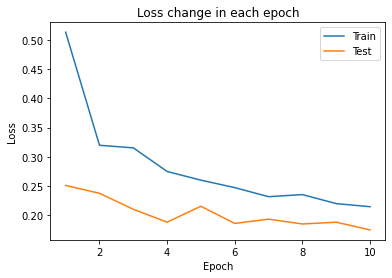

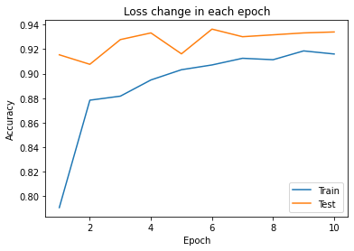

```python
plt.plot([1,2,3,4,5,6,7,8,9,10], history.history["loss"])
plt.plot([1,2,3,4,5,6,7,8,9,10], history.history["val_loss"])
plt.legend(["Train", "Test"])
plt.xlabel('Epoch')
plt.ylabel('Loss')
plt.title('Loss change in each epoch')
plt.show()
plt.plot([1,2,3,4,5,6,7,8,9,10], history.history["accuracy"])
plt.plot([1,2,3,4,5,6,7,8,9,10], history.history["val_accuracy"])
plt.legend(["Train", "Test"])
plt.xlabel('Epoch')
plt.ylabel('Accuracy')
plt.title('Loss change in each epoch')
plt.show()
```

```python
input_layer = layers.Input(shape=(80,80,1))
output_layer = layers.Flatten()(input_layer)
output_layer = layers.Dense(100, activation='relu')(output_layer)
output_layer = layers.Dense(100, activation='relu')(output_layer)
output_layer = layers.Dense(3, activation='softmax')(output_layer)
model = models.Model(inputs=input_layer, outputs=output_layer)
model.compile(optimizer=optimizers.SGD(learning_rate=0.01, momentum=0.9), loss='categorical_crossentropy', metrics=['accuracy', Recall, Precision, F1])
history = model.fit(train_data, validation_data=test_data , epochs=10)
```

```python
loss, accuracy, recall, precision, f1 = model.evaluate(test_data, verbose=0)
print("Loss = ",loss)
print("Accuarcy = ",accuracy)
print("Recall = ",recall)
print("Precision = ",precision)
print("F1 = ",f1)
```

```
Loss =  0.18068094551563263
Accuarcy =  0.9332298040390015
Recall =  0.9314024448394775
Precision =  0.9364393949508667
F1 =  0.9338693618774414
```

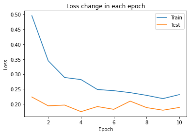

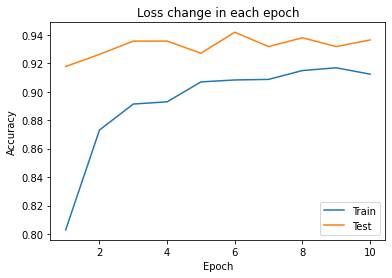

```python
plt.plot([1,2,3,4,5,6,7,8,9,10], history.history["loss"])
plt.plot([1,2,3,4,5,6,7,8,9,10], history.history["val_loss"])
plt.legend(["Train", "Test"])
plt.xlabel('Epoch')
plt.ylabel('Loss')
plt.title('Loss change in each epoch')
plt.show()
plt.plot([1,2,3,4,5,6,7,8,9,10], history.history["accuracy"])
plt.plot([1,2,3,4,5,6,7,8,9,10], history.history["val_accuracy"])
plt.legend(["Train", "Test"])
plt.xlabel('Epoch')
plt.ylabel('Accuracy')
plt.title('Loss change in each epoch')
plt.show()
```

```python
input_layer = layers.Input(shape=(80,80,1))
output_layer = layers.Flatten()(input_layer)
output_layer = layers.Dense(100, activation='relu')(output_layer)
output_layer = layers.Dense(100, activation='relu')(output_layer)
output_layer = layers.Dense(3, activation='softmax')(output_layer)
model = models.Model(inputs=input_layer, outputs=output_layer)
model.compile(optimizer=optimizers.SGD(learning_rate=0.01, momentum=0.99), loss='categorical_crossentropy', metrics=['accuracy', Recall, Precision, F1])
history = model.fit(train_data, validation_data=test_data , epochs=10)
```

```python
loss, accuracy, recall, precision, f1 = model.evaluate(test_data, verbose=0)
print("Loss = ",loss)
print("Accuarcy = ",accuracy)
print("Recall = ",recall)
print("Precision = ",precision)
print("F1 = ",f1)
```

```
Loss =  0.8343580961227417
Accuarcy =  0.6638198494911194
Recall =  0.6653963327407837
Precision =  0.6653963327407837
F1 =  0.6653962731361389
```

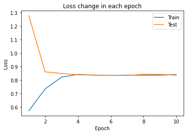

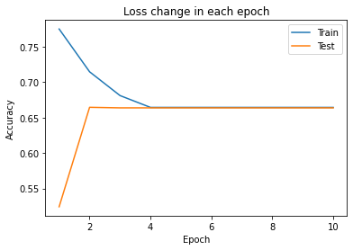

```python
plt.plot([1,2,3,4,5,6,7,8,9,10], history.history["loss"])
plt.plot([1,2,3,4,5,6,7,8,9,10], history.history["val_loss"])
plt.legend(["Train", "Test"])
plt.xlabel('Epoch')
plt.ylabel('Loss')
plt.title('Loss change in each epoch')
plt.show()
plt.plot([1,2,3,4,5,6,7,8,9,10], history.history["accuracy"])
plt.plot([1,2,3,4,5,6,7,8,9,10], history.history["val_accuracy"])
plt.legend(["Train", "Test"])
plt.xlabel('Epoch')
plt.ylabel('Accuracy')
plt.title('Loss change in each epoch')
plt.show()
```

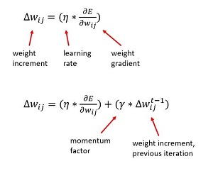

In top image, we can see `delta of weight`, which updates the wights in neural network.

Using momentum, the modified update rule is shown as the bottom formula in Figure 1. In words, "the weight delta equals the learning rate times the gradient, plus a momentum factor times the weight delta from the previous iteration." For example, if during training a weight has a value of 3.56, the learning rate is set to 0.10, the computed gradient is 4.70, the momentum factor is set to 0.50, and the value of the weight delta from the previous training iteration was 0.62, then the weight delta is (0.10 x 4.70) + (0.50 x 0.62) = 0.47 + 0.31 = 0.78, and so the new value of the weight is 3.56 + 0.78 = 4.34.

When training a neural network, you must experiment with different momentum factor values. In some situations, using no momentum (or equivalently, a momentum factor of 0.0) leads to better results than using momentum. However, in most scenarios, using momentum gives you faster training and better predictive accuracy.

But maybe usign high momentum, we get very high learning rate which changes wight and bias a lot that is not good.